# **Assignment : DT**

**Please check below video before attempting this assignment**

**TF-IDFW2V**

**Tfidf w2v (w1,w2..) = (tfidf(w1) * w2v(w1) + tfidf(w2) * w2v(w2) + …) / (tfidf(w1) + tfidf(w2) + …)**

**(Optional) Please check course video on [AVgw2V and TF-IDFW2V](https://www.appliedaicourse.com/lecture/11/applied-machine-learning-online-course/2916/avg-word2vec-tf-idf-weighted-word2vec/3/module-3-foundations-of-natural-language-processing-and-machine-learning) for more details.**

**Glove vectors**

**In this assignment you will be working with glove vectors , please check [this](https://en.wikipedia.org/wiki/GloVe_(machine_learning)) and [this](https://en.wikipedia.org/wiki/GloVe_(machine_learning)) for more details.**

Download glove vectors from this [link](https://drive.google.com/file/d/1lDca_ge-GYO0iQ6_XDLWePQFMdAA2b8f/view?usp=sharing)

```python
%matplotlib inline
import warnings
warnings.filterwarnings("ignore")

import pandas as pd
import numpy as np
import nltk
import matplotlib.pyplot as plt
import seaborn as sns
from sklearn.feature_extraction.text import TfidfVectorizer
from sklearn.feature_extraction.text import CountVectorizer
from sklearn.metrics import confusion_matrix
from sklearn import metrics
from sklearn.metrics import roc_curve, auc

import re
# Tutorial about Python regular expressions: https://pymotw.com/2/re/

import pickle
from tqdm import tqdm
import os
```

```python
from google.colab import drive

drive.mount('/content/drive')
```

```python
#!ls "/content/drive/My Drive"
```

or else , you can use below code

```python
'''
# Reading glove vectors in python: https://stackoverflow.com/a/38230349/4084039
def loadGloveModel(gloveFile):
    print ("Loading Glove Model")
    f = open(gloveFile,'r', encoding="utf8")
    model = {}
    for line in tqdm(f):
        splitLine = line.split()
        word = splitLine[0]
        embedding = np.array([float(val) for val in splitLine[1:]])
        model[word] = embedding
    print ("Done.",len(model)," words loaded!")
    return model
model = loadGloveModel('glove.42B.300d.txt')

# ============================
Output:

Loading Glove Model
1917495it [06:32, 4879.69it/s]
Done. 1917495  words loaded!

# ============================

words = []
for i in preproced_texts:
    words.extend(i.split(' '))

for i in preproced_titles:
    words.extend(i.split(' '))
print("all the words in the coupus", len(words))
words = set(words)
print("the unique words in the coupus", len(words))

inter_words = set(model.keys()).intersection(words)
print("The number of words that are present in both glove vectors and our coupus", \
      len(inter_words),"(",np.round(len(inter_words)/len(words)*100,3),"%)")

words_courpus = {}
words_glove = set(model.keys())
for i in words:
    if i in words_glove:
        words_courpus[i] = model[i]
print("word 2 vec length", len(words_courpus))


# stronging variables into pickle files python: http://www.jessicayung.com/how-to-use-pickle-to-save-and-load-variables-in-python/

import pickle
with open('glove_vectors', 'wb') as f:
    pickle.dump(words_courpus, f)


'''
```

[output not shown]

# **Task - 1**

1. **Apply Decision Tree Classifier(DecisionTreeClassifier) on these feature sets**
   - Set 1: categorical, numerical features + preprocessed_essay (TFIDF) + Sentiment scores(preprocessed_essay)
   - Set 2: categorical, numerical features + preprocessed_essay (TFIDF W2V) + Sentiment scores(preprocessed_essay)

[figure not shown]

         with X-axis as **min_sample_split**, Y-axis as **max_depth**, and Z-axis as **AUC Score** , we have given the notebook which explains how to plot this 3d plot, you can find it in the same drive *3d_scatter_plot.ipynb*

       **or**
       - You need to plot the performance of model both on train data and cross validation data for each hyper parameter, like shown in the figure

[figure not shown]

         [seaborn heat maps](https://seaborn.pydata.org/generated/seaborn.heatmap.html) with rows as **min_sample_split**, columns as **max_depth**, and values inside the cell representing **AUC Score**
       - You choose either of the plotting techniques out of 3d plot or heat map
       - Once after you found the best hyper parameter, you need to train your model with it, and find the AUC on test data and plot the ROC curve on both train and test.

[figure not shown]

       - Along with plotting ROC curve, you need to print the [confusion matrix](https://www.appliedaicourse.com/course/applied-ai-course-online/lessons/confusion-matrix-tpr-fpr-fnr-tnr-1/) with predicted and original labels of test data points

[figure not shown]

       - Once after you plot the confusion matrix with the test data, get all the `false positive data points`
         - Plot the WordCloud(https://www.geeksforgeeks.org/generating-word-cloud-python/) with the words of essay text of these `false positive data points`
         - Plot the box plot with the `price` of these `false positive data points`
         - Plot the pdf with the `teacher_number_of_previously_posted_projects` of these `false positive data points`

# **Task - 2**

For this task consider **set-1** features.

- Select all the features which are having non-zero feature importance.You can get the feature importance using 'feature*importances*` (https://scikit-learn.org/stable/modules/generated/sklearn.tree.DecisionTreeClassifier.html), discard the all other remaining features and then apply any of the model of you choice i.e. (Dession tree, Logistic Regression, Linear SVM).
- You need to do hyperparameter tuning corresponding to the model you selected and procedure in step 2 and step 3  
  **Note**: when you want to find the feature importance make sure you don't use max_depth parameter keep it None. </li>  
  You need to summarize the results at the end of the notebook, summarize it in the table format

# 1. Decision Tree

## 1.1 Loading Data

```python
import pandas as pd
import io

data = pd.read_csv('/content/drive/MyDrive/preprocessed_data.csv',nrows=50000)
#https://drive.google.com/file/d/184Ev6rBreIbWTHALM6A7WIPh-ZUzNFjO/view?usp=sharing
data.head(1)
```

|  | school_state | teacher_prefix | project_grade_category | teacher_number_of_previously_posted_projects | project_is_approved | clean_categories | clean_subcategories | essay | price |
| --- | --- | --- | --- | --- | --- | --- | --- | --- | --- |
| 0 | ca | mrs | grades_prek_2 | 53 | 1 | math_science | appliedsciences health_lifescience | i fortunate enough use fairy tale stem kits cl... | 725.05 |

```python
# please write all the code with proper documentation, and proper titles for each subsection
# go through documentations and blogs before you start coding
# first figure out what to do, and then think about how to do.
# reading and understanding error messages will be very much helpfull in debugging your code
# when you plot any graph make sure you use
    # a. Title, that describes your plot, this will be very helpful to the reader
    # b. Legends if needed
    # c. X-axis label
    # d. Y-axis label
```

**Apply Decision Tree Classifier(DecisionTreeClassifier) on these feature sets**

```python
#notes:Stratified Sampling means

from sklearn.model_selection import train_test_split
y = data['project_is_approved'].values
X = data.drop(['project_is_approved'], axis=1)
X_train, X_test, y_train, y_test = train_test_split(X, y, test_size=0.33, stratify=y)
X_train, X_cv, y_train, y_cv = train_test_split(X_train, y_train, test_size=0.33, stratify=y_train)
```

```python
X.head(1)
```

|  | school_state | teacher_prefix | project_grade_category | teacher_number_of_previously_posted_projects | clean_categories | clean_subcategories | essay | price |
| --- | --- | --- | --- | --- | --- | --- | --- | --- |
| 0 | ca | mrs | grades_prek_2 | 53 | math_science | appliedsciences health_lifescience | i fortunate enough use fairy tale stem kits cl... | 725.05 |

```python
print(X_train.shape)
print(X_test.shape)
print(X_cv.shape)
```

```
(22445, 8)
(16500, 8)
(11055, 8)
```

## 1.3 Make Data Model Ready: encoding essay

```python
from sklearn.feature_extraction.text import TfidfVectorizer


#tfidf vectorizer
vectorizertfidf=TfidfVectorizer(min_df=10)
vectorizertfidf.fit(X_train['essay'])
X_train_essay_tfidf = vectorizertfidf.transform(X_train['essay'].values)
X_cv_essay_tfidf = vectorizertfidf.transform(X_cv['essay'].values)
X_test_essay_tfidf = vectorizertfidf.transform(X_test['essay'].values)

print(X_train_essay_tfidf.shape)
```

```
(22445, 8835)
```

```python
#school_state

vectorizer3 = CountVectorizer(lowercase=False, binary=True)
vectorizer3.fit(X_train['school_state'].values) # fit has to happen only on train data

# we use the fitted Countvectorizer3 to convert the text to vector
X_train_state_ohe = vectorizer3.transform(X_train['school_state'].values)
X_cv_state_ohe = vectorizer3.transform(X_cv['school_state'].values)
X_test_state_ohe = vectorizer3.transform(X_test['school_state'].values)

print(X_train_state_ohe.shape)
```

```
(22445, 51)
```

```python
#Teacher Prefix

vectorizer4 = CountVectorizer(lowercase=False, binary=True)
vectorizer4.fit(X_train['teacher_prefix'].values) # fit has to happen only on train data

# we use the fitted CountVectorizer to convert the text to vector

X_train_teacher_ohe = vectorizer4.transform(X_train['teacher_prefix'].values)
X_cv_teacher_ohe = vectorizer4.transform(X_cv['teacher_prefix'].values)
X_test_teacher_ohe = vectorizer4.transform(X_test['teacher_prefix'].values)
print(X_train_teacher_ohe.shape)
```

```
(22445, 5)
```

```python
#project_grade_category
vectorizer5 = CountVectorizer(lowercase=False, binary=True)
vectorizer5.fit(X_train['project_grade_category'].values) # fit has to happen only on train data

# we use the fitted CountVectorizer to convert the text to vector
X_train_project_grade_category = vectorizer5.transform(X_train['project_grade_category'].values)
X_cv_project_grade_category = vectorizer5.transform(X_cv['project_grade_category'].values)
X_test_project_grade_category = vectorizer5.transform(X_test['project_grade_category'].values)
print(X_train_project_grade_category.shape)
```

```
(22445, 4)
```

```python
#teacher_number_of_previously_posted_projects
from sklearn.preprocessing import Normalizer
normalizer = Normalizer()
normalizer.fit(X_train['teacher_number_of_previously_posted_projects'].values.reshape(-1,1)) # fit has to happen only on train data

# we use the fitted CountVectorizer to convert the text to vector
X_train_teacher_number_of_previously_posted_projects = normalizer.transform(X_train['teacher_number_of_previously_posted_projects'].values.reshape(-1,1))
X_cv_teacher_number_of_previously_posted_projects = normalizer.transform(X_cv['teacher_number_of_previously_posted_projects'].values.reshape(-1,1))
X_test_teacher_number_of_previously_posted_projects = normalizer.transform(X_test['teacher_number_of_previously_posted_projects'].values.reshape(-1,1))
print(X_train_teacher_number_of_previously_posted_projects.shape)
```

```
(22445, 1)
```

```python
#clean_categories
vectorizer6 = CountVectorizer()
vectorizer6.fit(X_train['clean_categories'].values) # fit has to happen only on train data

# we use the fitted CountVectorizer to convert the text to vector
X_train_clean_categories= vectorizer6.transform(X_train['clean_categories'].values)
X_cv_clean_categories = vectorizer6.transform(X_cv['clean_categories'].values)
X_test_clean_categories= vectorizer6.transform(X_test['clean_categories'].values)
print(X_train_clean_categories.shape)
```

```
(22445, 9)
```

```python
#clean_subcategories

vectorizer2 = CountVectorizer()
vectorizer2.fit(X_train['clean_subcategories'].values) # fit has to happen only on train data

# we use the fitted CountVectorizer to convert the text to vector
X_train_clean_subcategories = vectorizer2.transform(X_train['clean_subcategories'].values)
X_cv_clean_subcategories = vectorizer2.transform(X_cv['clean_subcategories'].values)
X_test_clean_subcategories = vectorizer2.transform(X_test['clean_subcategories'].values)

print(X_train_clean_subcategories.shape)
```

```
(22445, 30)
```

```python
#Price
#vectorizer for vectoring the words
#normalizer for normalizing the integer values

from sklearn.preprocessing import Normalizer
normalizer = Normalizer()
normalizer.fit(X_train['price'].values.reshape(-1,1)) # fit has to happen only on train data

# we use the fitted CountVectorizer to convert the text to vector
X_train_price = normalizer.transform(X_train['price'].values.reshape(-1,1))
X_cv_price = normalizer.transform(X_cv['price'].values.reshape(-1,1))
X_test_price = normalizer.transform(X_test['price'].values.reshape(-1,1))
print(X_train_price.shape)
print(X_cv_price.shape)
print(X_test_price.shape)
```

```
(22445, 1)
(11055, 1)
(16500, 1)
```

```python
from scipy.sparse import hstack
#hstackign getting all the data and combining
X_tr = hstack((X_train_essay_tfidf,X_train_state_ohe,X_train_teacher_ohe,X_train_project_grade_category, X_train_teacher_number_of_previously_posted_projects,X_train_clean_categories,X_train_clean_subcategories)).tocsr()
X_cr = hstack((X_cv_essay_tfidf,X_cv_state_ohe,X_cv_teacher_ohe,X_cv_project_grade_category, X_cv_teacher_number_of_previously_posted_projects,X_cv_clean_categories,X_cv_clean_subcategories)).tocsr()
X_te = hstack((X_test_essay_tfidf,X_test_state_ohe,X_test_teacher_ohe,X_test_project_grade_category, X_test_teacher_number_of_previously_posted_projects,X_test_clean_categories,X_test_clean_subcategories)).tocsr()

print(X_tr.shape)
print(X_cr.shape)
print(X_te.shape)
```

```
(22445, 8935)
(11055, 8935)
(16500, 8935)
```

```python
#from reffernce aaic code for NB assignment
def batch_predict(clf, data):
    # roc_auc_score(y_true, y_score) the 2nd parameter should be probability estimates of the positive class
    # not the predicted outputs

    y_data_pred = []
    tr_loop = data.shape[0] - data.shape[0]%1000

    # consider you X_tr shape is 49041, then your tr_loop will be 49041 - 49041%1000 = 49000
    # in this for loop we will iterate unti the last 1000 multiplier
    for i in range(0, tr_loop, 1000):
        y_data_pred.extend(clf.predict_proba(data[i:i+1000])[:,1])
    # we will be predicting for the last data points
    if data.shape[0]%1000 !=0:
        y_data_pred.extend(clf.predict_proba(data[tr_loop:])[:,1])

    return y_data_pred
```

Hyperparameter tuning using Gridsearch for different value of the depth and split

```python
#https://github.com/RameshBattu/Apply-Decision-Trees-on-Donors-Choose-dataset
from sklearn.metrics import roc_auc_score
import matplotlib.pyplot as plt
from sklearn.model_selection import GridSearchCV
from sklearn.model_selection import cross_val_score
from sklearn.tree import DecisionTreeClassifier
decision_tree = DecisionTreeClassifier(class_weight = 'balanced')
parameters = {'max_depth': [1, 5, 10,50], 'min_samples_split': [5, 10,100,500]}
clf1 = GridSearchCV(decision_tree, parameters, cv=3, scoring='roc_auc',return_train_score=True)
se1 = clf1.fit(X_tr, y_train)
```

ref https://towardsdatascience.com/decision-trees-a-birds-eye-view-and-an-implementation-c91754f0dcd0

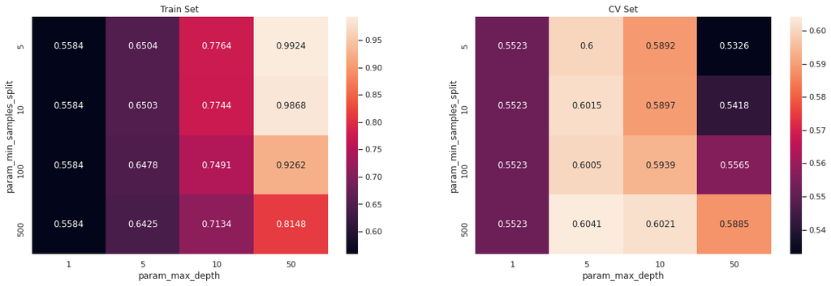

```python
# ploting the performance of model both on train data and cross validation data for each hyper parameter
#https://seaborn.pydata.org/generated/seaborn.heatmap.html
import seaborn as sns; sns.set()
#https://seaborn.pydata.org/generated/seaborn.heatmap.html
max_scores1 = pd.DataFrame(clf1.cv_results_).groupby(['param_min_samples_split', 'param_max_depth']).max().unstack()[['mean_test_score', 'mean_train_score']]

fig, ax = plt.subplots(1,2, figsize=(20,6))
sns.heatmap(max_scores1.mean_train_score, annot = True, fmt='.4g', ax=ax[0])
sns.heatmap(max_scores1.mean_test_score, annot = True, fmt='.4g', ax=ax[1])
ax[0].set_title('Train Set')
ax[1].set_title('CV Set')
plt.show()
```

```python
# Best tune parameters with score
print(clf1.best_estimator_)
print(clf1.score(X_tr,y_train))
print(clf1.score(X_te,y_test))
```

```
DecisionTreeClassifier(ccp_alpha=0.0, class_weight='balanced', criterion='gini',
                       max_depth=5, max_features=None, max_leaf_nodes=None,
                       min_impurity_decrease=0.0, min_impurity_split=None,
                       min_samples_leaf=1, min_samples_split=500,
                       min_weight_fraction_leaf=0.0, presort='deprecated',
                       random_state=None, splitter='best')
0.6392560843789082
0.6062399400035551
```

```python
best_tune_parameters=[{'max_depth':[10], 'min_samples_split':[500]}]
best_tune_parameters
```

```
[{'max_depth': [10], 'min_samples_split': [500]}]
```

```
CPU times: user 2 µs, sys: 0 ns, total: 2 µs
Wall time: 4.29 µs
```

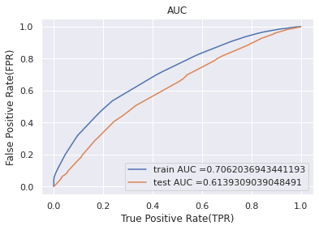

```python
%time
from sklearn.metrics import auc,roc_curve

clf1_best =DecisionTreeClassifier(class_weight = 'balanced',max_depth=10,min_samples_split=500)
clf1_best.fit(X_tr,y_train)
# roc_auc_score(y_true, y_score) the 2nd parameter should be probability estimates of the positive class
# not the predicted outputs

y_train_pred = batch_predict(clf1_best, X_tr)
y_test_pred = batch_predict(clf1_best, X_te)

train_fpr, train_tpr, tr_thresholds = roc_curve(y_train,clf1_best.predict_proba(X_tr)[:,1])
test_fpr, test_tpr, te_thresholds = roc_curve(y_test, clf1_best.predict_proba(X_te)[:,1])

plt.plot(train_fpr, train_tpr, label="train AUC ="+str(auc(train_fpr, train_tpr)))
plt.plot(test_fpr, test_tpr, label="test AUC ="+str(auc(test_fpr, test_tpr)))

plt.legend()
plt.grid(True)
plt.xlabel("True Positive Rate(TPR)")
plt.ylabel("False Positive Rate(FPR)")
plt.title("AUC")
plt.show()
```

```python
def predict(proba, threshould, fpr, tpr):
    t = threshould[np.argmax(fpr*(1-tpr))]
    # (tpr*(1-fpr)) will be maximum if your fpr is very low and tpr is very high
    print("the maximum value of tpr*(1-fpr)", max(tpr*(1-fpr)), "for threshold", np.round(t,3))
    predictions = []
    for i in proba:
        if i>=t:
            predictions.append(1)
        else:
            predictions.append(0)
    return predictions
```

```python
print("="*100)
from sklearn.metrics import confusion_matrix
print("Train confusion matrix")
print(confusion_matrix(y_train, predict(y_train_pred, tr_thresholds, train_fpr, train_fpr)))
```

```
====================================================================================================
Train confusion matrix
the maximum value of tpr*(1-fpr) 0.24710289557626205 for threshold 0.433
[[ 1991  1604]
 [ 5220 13630]]
```

```python
tfidf_feature_names = []

for a in vectorizer2.get_feature_names():
    tfidf_feature_names.append(a);

for a in vectorizertfidf.get_feature_names():
    tfidf_feature_names.append(a);

for a in vectorizer3.get_feature_names():
    tfidf_feature_names.append(a);

for a in vectorizer4.get_feature_names():
    tfidf_feature_names.append(a);

for a in vectorizer5.get_feature_names():
    tfidf_feature_names.append(a);

for a in vectorizer6.get_feature_names():
    tfidf_feature_names.append(a);

tfidf_feature_names.append('Price');

len(tfidf_feature_names)

print(tfidf_feature_names[0:20])
```

```
['appliedsciences', 'care_hunger', 'charactereducation', 'civics_government', 'college_careerprep', 'communityservice', 'earlydevelopment', 'economics', 'environmentalscience', 'esl', 'extracurricular', 'financialliteracy', 'foreignlanguages', 'gym_fitness', 'health_lifescience', 'health_wellness', …
```

```python
import graphviz
from sklearn import tree
from graphviz import Source

#dot_data = tree.export_graphviz(clf1_best, out_file=None, feature_names=bow_feature_names)

dot_data = tree.export_graphviz(clf1_best, out_file=None,feature_names=tfidf_feature_names)
graph = graphviz.Source(dot_data)
graph.render("TFIDF tree",view = True)
```

```
'TFIDF tree.pdf'
```

# **SET2:AVG WORD2VECT**

```python
with open('/content/drive/MyDrive/glove_vectors', 'rb') as f:
    model = pickle.load(f)
    glove_words =  set(model.keys())
```

```python
'''
# Reading glove vectors in python: https://stackoverflow.com/a/38230349/4084039
def loadGloveModel(gloveFile):
    print ("Loading Glove Model")
    f = open(gloveFile,'r', encoding="utf8")
    model = {}
    for line in tqdm(f):
        splitLine = line.split()
        word = splitLine[0]
        embedding = np.array([float(val) for val in splitLine[1:]])
        model[word] = embedding
    print ("Done.",len(model)," words loaded!")
    return model
model = loadGloveModel('glove.42B.300d.txt')

# ============================
Output:

Loading Glove Model
1917495it [06:32, 4879.69it/s]
Done. 1917495  words loaded!

# ============================

words = []
for i in preproced_texts:
    words.extend(i.split(' '))

for i in preproced_titles:
    words.extend(i.split(' '))
print("all the words in the coupus", len(words))
words = set(words)
print("the unique words in the coupus", len(words))

inter_words = set(model.keys()).intersection(words)
print("The number of words that are present in both glove vectors and our coupus", \
      len(inter_words),"(",np.round(len(inter_words)/len(words)*100,3),"%)")

words_courpus = {}
words_glove = set(model.keys())
for i in words:
    if i in words_glove:
        words_courpus[i] = model[i]
print("word 2 vec length", len(words_courpus))


# stronging variables into pickle files python: http://www.jessicayung.com/how-to-use-pickle-to-save-and-load-variables-in-python/

import pickle
with open('glove_vectors', 'wb') as f:
    pickle.dump(words_courpus, f)


'''
```

[output not shown]

# SET-2 avg w2v for essay

```python
essays_avg_w2v_vectors_train = []; # the avg-w2v for each sentence/review is stored in this list
for sentence in tqdm(X_train['essay']): # for each review/sentence
    vector = np.zeros(300) # as word vectors are of zero length
    cnt_words =0; # num of words with a valid vector in the sentence/review
    for word in sentence.split(): # for each word in a review/sentence
        if word in glove_words:
            vector += model[word]
            cnt_words += 1
    if cnt_words != 0:
        vector /= cnt_words
    essays_avg_w2v_vectors_train.append(vector)

print(len(essays_avg_w2v_vectors_train))
print(len(essays_avg_w2v_vectors_train[0]))
```

```
22445
300
```

```python
essays_avg_w2v_vectors_test = []; # the avg-w2v for each sentence/review is stored in this list
for sentence in tqdm(X_test['essay']): # for each review/sentence
    vector = np.zeros(300) # as word vectors are of zero length
    cnt_words =0; # num of words with a valid vector in the sentence/review
    for word in sentence.split(): # for each word in a review/sentence
        if word in glove_words:
            vector += model[word]
            cnt_words += 1
    if cnt_words != 0:
        vector /= cnt_words
    essays_avg_w2v_vectors_test.append(vector)

print(len(essays_avg_w2v_vectors_test))
print(len(essays_avg_w2v_vectors_test[0]))
```

```
16500
300
```

```python
essays_avg_w2v_vectors_cv = []; # the avg-w2v for each sentence/review is stored in this list
for sentence in tqdm(X_cv['essay']): # for each review/sentence
    vector = np.zeros(300) # as word vectors are of zero length
    cnt_words =0; # num of words with a valid vector in the sentence/review
    for word in sentence.split(): # for each word in a review/sentence
        if word in glove_words:
            vector += model[word]
            cnt_words += 1
    if cnt_words != 0:
        vector /= cnt_words
    essays_avg_w2v_vectors_cv.append(vector)

print(len(essays_avg_w2v_vectors_cv))
print(len(essays_avg_w2v_vectors_cv[0]))
```

```
11055
300
```

```python
from scipy.sparse import hstack

X_tr2 = hstack((X_train_state_ohe,X_train_teacher_ohe,X_train_project_grade_category, X_train_teacher_number_of_previously_posted_projects,X_train_clean_categories,X_train_clean_subcategories,essays_avg_w2v_vectors_train)).tocsr()
X_cr2 = hstack((X_cv_state_ohe,X_cv_teacher_ohe,X_cv_project_grade_category, X_cv_teacher_number_of_previously_posted_projects,X_cv_clean_categories,X_cv_clean_subcategories,essays_avg_w2v_vectors_cv)).tocsr()
X_te2 = hstack((X_test_state_ohe,X_test_teacher_ohe,X_test_project_grade_category, X_test_teacher_number_of_previously_posted_projects,X_test_clean_categories,X_test_clean_subcategories,essays_avg_w2v_vectors_test)).tocsr()

print(X_tr2.shape)
print(X_cr2.shape)
print(X_te2.shape)
```

```
(22445, 400)
(11055, 400)
(16500, 400)
```

```python
#https://github.com/RameshBattu/Apply-Decision-Trees-on-Donors-Choose-dataset
from sklearn.metrics import roc_auc_score
import matplotlib.pyplot as plt
from sklearn.model_selection import GridSearchCV
from sklearn.model_selection import cross_val_score
from sklearn.tree import DecisionTreeClassifier
decision_tree = DecisionTreeClassifier(class_weight = 'balanced')
parameters = {'max_depth': [1, 5, 10,50], 'min_samples_split': [5, 10,100,500]}
clf2 = GridSearchCV(decision_tree, parameters, cv=3, scoring='roc_auc',return_train_score=True)
se1 = clf2.fit(X_tr2, y_train)
```

ref https://towardsdatascience.com/decision-trees-a-birds-eye-view-and-an-implementation-c91754f0dcd0

[figure not shown]

```python
# ploting the performance of model both on train data and cross validation data for each hyper parameter
import seaborn as sns; sns.set()
max_scores2 = pd.DataFrame(clf1.cv_results_).groupby(['param_min_samples_split', 'param_max_depth']).max().unstack()[['mean_test_score', 'mean_train_score']]
#ref:https://stackoverflow.com/questions/56302647/how-to-plot-a-heatmap-and-find-best-hyperparameter-for-decision-tree-after-grids

fig, ax = plt.subplots(1,2, figsize=(20,6))
sns.heatmap(max_scores2.mean_train_score, annot = True, fmt='.4g', ax=ax[0])
sns.heatmap(max_scores2.mean_test_score, annot = True, fmt='.4g', ax=ax[1])
ax[0].set_title('Train Set')
ax[1].set_title('CV Set')
plt.show()
```

```python
# Best tune parameters with score
print(clf2.best_estimator_)
print(clf2.score(X_tr2,y_train))
print(clf2.score(X_te2,y_test))
```

```
DecisionTreeClassifier(ccp_alpha=0.0, class_weight='balanced', criterion='gini',
                       max_depth=5, max_features=None, max_leaf_nodes=None,
                       min_impurity_decrease=0.0, min_impurity_split=None,
                       min_samples_leaf=1, min_samples_split=500,
                       min_weight_fraction_leaf=0.0, presort='deprecated',
                       random_state=None, splitter='best')
0.6707444099711137
0.5959034694826699
```

```python
best_tune_parameters=[{'max_depth':[5], 'min_samples_split':[500]}]
best_tune_parameters
```

```
[{'max_depth': [5], 'min_samples_split': [500]}]
```

```
CPU times: user 2 µs, sys: 0 ns, total: 2 µs
Wall time: 4.53 µs
```

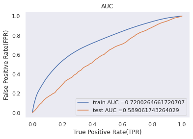

```python
%time
from sklearn.metrics import auc,roc_curve

clf2_best =DecisionTreeClassifier (class_weight = 'balanced',max_depth=10,min_samples_split=500)
clf2_best.fit(X_tr2,y_train)
# roc_auc_score(y_true, y_score) the 2nd parameter should be probability estimates of the positive class
# not the predicted outputs

y_train_pred = batch_predict(clf2_best, X_tr2)
y_test_pred = batch_predict(clf2_best, X_te2)

train_fpr2, train_tpr2, tr_thresholds2 = roc_curve(y_train,clf2_best.predict_proba(X_tr2)[:,1])
test_fpr2, test_tpr2, te_thresholds2 = roc_curve(y_test, clf2_best.predict_proba(X_te2)[:,1])

plt.plot(train_fpr2, train_tpr2, label="train AUC ="+str(auc(train_fpr2, train_tpr2)))
plt.plot(test_fpr2, test_tpr2, label="test AUC ="+str(auc(test_fpr2, test_tpr2)))


plt.legend()
plt.grid(False)
plt.xlabel("True Positive Rate(TPR)")
plt.ylabel("False Positive Rate(FPR)")
plt.title("AUC")
plt.show()
```

AUC SCORE FOR 10 AND SAMPLE 500=0.6

```python
#https://graphviz.org/
"""dot draws directed graphs as hierarchies. It runs as a command line program, web visualization service, or with a compatible graphical interface.
Its features include well-tuned layout algorithms for placing nodes and edge
splines, edge labels, “record” shapes with “ports” for drawing data structures; cluster layouts; and an underlying file language for stream-oriented
graph tools"""
import graphviz
from sklearn import tree
from graphviz import Source

#dot_data = tree.export_graphviz(clf1_best, out_file=None, feature_names=bow_feature_names)

dot_data = tree.export_graphviz(clf2_best, out_file=None, )
graph = graphviz.Source(dot_data)
graph.render("avgw2v tree",view = True)
```

```
'avgw2v tree.pdf'
```

```python
def predict(proba, threshould, fpr, tpr):
    t = threshould[np.argmax(fpr*(1-tpr))]
    #fpr.append()

    # (tpr*(1-fpr)) will be maximum if your fpr is very low and tpr is very high
    print("the maximum value of tpr*(1-fpr)", max(tpr*(1-fpr)), "for threshold", np.round(t,3))
    predictions = []

    for i in proba:
        if i>=t:
            predictions.append(1)
        else:
            predictions.append(0)
    return predictions
```

```python
print("="*100)
from sklearn.metrics import confusion_matrix
print("Train confusion matrix")
print(confusion_matrix(y_train, predict(y_train_pred, tr_thresholds2, train_fpr2, train_tpr2)))
```

```
====================================================================================================
Train confusion matrix
the maximum value of tpr*(1-fpr) 0.4513589829670593 for threshold 0.393
[[ 2082  1513]
 [ 5045 13805]]
```

```python
print("="*100)
from sklearn.metrics import confusion_matrix
print("Test confusion matrix")
print(confusion_matrix(y_test, predict(y_test_pred, tr_thresholds2, test_fpr2, test_tpr2)))
```

```
====================================================================================================
Test confusion matrix
the maximum value of tpr*(1-fpr) 0.3193024162345687 for threshold 0.546
[[1592 1050]
 [6709 7149]]
```

Once after you plot the confusion matrix with the test data, get all the `false positive data points` Plot the WordCloud(https://www.geeksforgeeks.org/generating-word-cloud-python/) with the words of essay text of these `false positive data points` Plot the box plot with the `price` of these `false positive data points` Plot the pdf with the `teacher_number_of_previously_posted_projects` of these `false positive data points`

```python
#Cite : https://datascience.stackexchange.com/questions/28493/confusion-matrix-get-items
fp =[]
for i in range(len(y_test)):
  if (y_test[i] == 0) & (y_test_pred[i] == 1) :
    fp.append(i)
fpr_essay_2 = []
for i in fp:
  fpr_essay_2.append(X_test['essay'].values[i])
print(len(fp))
```

```
11
```

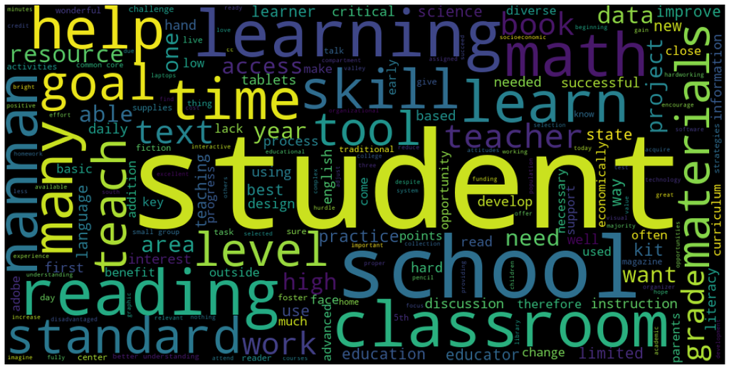

```python
from wordcloud import WordCloud

unique_string=(" ").join(fpr_essay_2)
wordcloud = WordCloud(width = 1000, height = 500).generate(unique_string)
plt.figure(figsize=(25,10))
plt.imshow(wordcloud)
plt.axis("off")
plt.savefig("your_file_name"+".png", bbox_inches='tight')
plt.show()
plt.close()
```

Plot the box plot with the price of these false positive data points

```python
#first get the columns:
cols = X_test.columns
X_test_fp = pd.DataFrame(columns=cols)
print(len(y_test))
fp =[]
for i in range(len(y_test)):
  if (y_test[i] == 0) & (y_test_pred[i] == 1) :
    fp.append(i)
print(len(fp))
# get the data of the false pisitives
for i in fp : # (in fpi all the false positives data points indexes)
  X_test_fp = X_test_fp.append(X_test.filter(items=[i], axis=0))
  X_test_fp.head(1)
len(X_test_fp)
print(len(X_test))
print(len(X_test_fp))
```

```
16500
11
16500
5
```

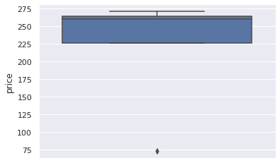

```python
sns.boxplot(y='price', data=X_test_fp)
```

```python
#pdf of the teacher
```

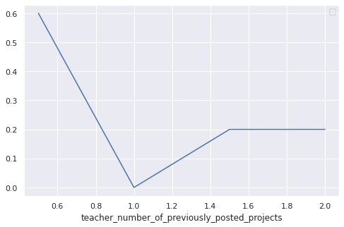

```python
plt.figure(figsize=(8,5))

counts, bin_edges = np.histogram(X_test_fp['teacher_number_of_previously_posted_projects'],bins='auto',density=True)

pdf = counts/sum(counts)

pdf_plot = plt.plot(bin_edges[1:],pdf)
plt.legend([pdf_plot], ["PDF"])
plt.xlabel('teacher_number_of_previously_posted_projects')
plt.show()
```

```python
from prettytable import PrettyTable

table = PrettyTable()

table.field_names = ['Set','Model','depth','min_samples_split','Train AUC Score','Test AUC Score']

table.add_row(['Set 1','Decision Tree TFIDF',10,500,0.70,0.61])
table.add_row(['Set 2','Decision Tree avgw2v',10,500,0.72,0.58])
print(table)
```

```
+-------+----------------------+-------+-------------------+-----------------+----------------+
|  Set  |        Model         | depth | min_samples_split | Train AUC Score | Test AUC Score |
+-------+----------------------+-------+-------------------+-----------------+----------------+
| Set 1 | Decision Tree TFIDF  |   10  |        500        |       0.7       |      0.61      |
| Set 2 | Decision Tree avgw2v |   10  |        500        |       0.72      |      0.58      |
+-------+----------------------+-------+-------------------+-----------------+----------------+
```